```python
import pandas as pd
import numpy as np
from matplotlib import pyplot as plt
import seaborn as sns
import plotly.offline as py
py.init_notebook_mode(connected=True)
import plotly.graph_objs as go
from plotly.offline import download_plotlyjs, init_notebook_mode, plot, iplot
from plotly import tools
```

# Factors relating to Academic Success

**Sex**:  
male (M) or female (F)  
**Age**:  
age (15-22)  
**Living**:  
living situation: urban setting (U) or rural setting (R)  
**Divorce**:  
divorce status: living together (T) or divorced (D)  
**Mom edu**:  
Mother's education: 0 = none, 1 = primary education (4th grade), 2 = (5th to 9th grade), 3 = (secondary education,) or 4= (higher education)  
**Dad edu**:  
Father's education: 0 = none, 1 = primary education (4th grade), 2 = (5th to 9th grade), 3 = (secondary education), or 4 = (higher education)  
**Guardian**:  
'mother', 'father' or 'other'  
**Study Time**:  
study time: 1 = (<2 hours), 2 = (2 to 5 hours), 3 = (5 to 10 hours), 4 = (>10 hours))  
**Failures**:  
Number of past class failures (numeric: n if 1<=n<3, else 4  
**Activities**:  
Extra-curricular activities: (yes) or (no)  
**Relationship**:  
A romantic relationship (yes) or (no)  
**Fam_quality**:  
Quality of family relationships (numeric: from 1 - very bad to 5 - excellent)  
**Free time**:  
Free time after school (numeric: from 1 - very low to 5 - very high)  
**Going out**:  
Going out with friends (numeric: from 1 - very low to 5 - very high)  
**Health**:  
Current health status (numeric: from 1 - very bad to 5 - very good)  
**Absences**:  
Number of school absences (numeric: from 0 to 93)  
**Final Grade**:  
Final grade (numeric: from 0 to 20)

# Reading the Data:

```python
# reading in the dataset for factors of academic success
data = pd.read_csv("academic_success.csv")
data.head()
```

|  | school | sex | age | address | famsize | Pstatus | Medu | Fedu | Mjob | Fjob | ... | famrel | freetime | goout | Dalc | Walc | health | absences | G1 | G2 | G3 |
| --- | --- | --- | --- | --- | --- | --- | --- | --- | --- | --- | --- | --- | --- | --- | --- | --- | --- | --- | --- | --- | --- |
| 0 | GP | F | 18 | U | GT3 | A | 4 | 4 | at_home | teacher | ... | 4 | 3 | 4 | 1 | 1 | 3 | 6 | 5 | 6 | 6 |
| 1 | GP | F | 17 | U | GT3 | T | 1 | 1 | at_home | other | ... | 5 | 3 | 3 | 1 | 1 | 3 | 4 | 5 | 5 | 6 |
| 2 | GP | F | 15 | U | LE3 | T | 1 | 1 | at_home | other | ... | 4 | 3 | 2 | 2 | 3 | 3 | 10 | 7 | 8 | 10 |
| 3 | GP | F | 15 | U | GT3 | T | 4 | 2 | health | services | ... | 3 | 2 | 2 | 1 | 1 | 5 | 2 | 15 | 14 | 15 |
| 4 | GP | F | 16 | U | GT3 | T | 3 | 3 | other | other | ... | 4 | 3 | 2 | 1 | 2 | 5 | 4 | 6 | 10 | 10 |

5 rows × 33 columns

# Cleaning & Tidying the Data:

```python
# dropping columns we will not be using in the study
data = data.drop(['school', 'traveltime', 'schoolsup', 'Mjob', 'Fjob', 'reason', 'failures', 'famsup', 'famsize','internet','paid', 'nursery', 'higher', 'G1', 'G2', 'Dalc', 'Walc'], axis =1)
data.head()
```

|  | sex | age | address | Pstatus | Medu | Fedu | guardian | studytime | activities | romantic | famrel | freetime | goout | health | absences | G3 |
| --- | --- | --- | --- | --- | --- | --- | --- | --- | --- | --- | --- | --- | --- | --- | --- | --- |
| 0 | F | 18 | U | A | 4 | 4 | mother | 2 | no | no | 4 | 3 | 4 | 3 | 6 | 6 |
| 1 | F | 17 | U | T | 1 | 1 | father | 2 | no | no | 5 | 3 | 3 | 3 | 4 | 6 |
| 2 | F | 15 | U | T | 1 | 1 | mother | 2 | no | no | 4 | 3 | 2 | 3 | 10 | 10 |
| 3 | F | 15 | U | T | 4 | 2 | mother | 3 | yes | yes | 3 | 2 | 2 | 5 | 2 | 15 |
| 4 | F | 16 | U | T | 3 | 3 | father | 2 | no | no | 4 | 3 | 2 | 5 | 4 | 10 |

```python
# cleaning the column names to make more sense
data.columns = ['sex', 'age', 'living', 'divorce?', 'mom_edu', 'dad_edu', 'guardian', 'study_time','activities', 'relationship', 'fam_quality', 'free_time', 'going_out', 'health', 'absences', 'grade']
data.head()
```

|  | sex | age | living | divorce? | mom_edu | dad_edu | guardian | study_time | activities | relationship | fam_quality | free_time | going_out | health | absences | grade |
| --- | --- | --- | --- | --- | --- | --- | --- | --- | --- | --- | --- | --- | --- | --- | --- | --- |
| 0 | F | 18 | U | A | 4 | 4 | mother | 2 | no | no | 4 | 3 | 4 | 3 | 6 | 6 |
| 1 | F | 17 | U | T | 1 | 1 | father | 2 | no | no | 5 | 3 | 3 | 3 | 4 | 6 |
| 2 | F | 15 | U | T | 1 | 1 | mother | 2 | no | no | 4 | 3 | 2 | 3 | 10 | 10 |
| 3 | F | 15 | U | T | 4 | 2 | mother | 3 | yes | yes | 3 | 2 | 2 | 5 | 2 | 15 |
| 4 | F | 16 | U | T | 3 | 3 | father | 2 | no | no | 4 | 3 | 2 | 5 | 4 | 10 |

```python
# changing the variable 'A' that represents 'Apart' to 'D' to represent 'Divorce' for clarity purposes
data['divorce?'] = data['divorce?'].replace('A', 'D')
data.head()
```

|  | sex | age | living | divorce? | mom_edu | dad_edu | guardian | study_time | activities | relationship | fam_quality | free_time | going_out | health | absences | grade |
| --- | --- | --- | --- | --- | --- | --- | --- | --- | --- | --- | --- | --- | --- | --- | --- | --- |
| 0 | F | 18 | U | D | 4 | 4 | mother | 2 | no | no | 4 | 3 | 4 | 3 | 6 | 6 |
| 1 | F | 17 | U | T | 1 | 1 | father | 2 | no | no | 5 | 3 | 3 | 3 | 4 | 6 |
| 2 | F | 15 | U | T | 1 | 1 | mother | 2 | no | no | 4 | 3 | 2 | 3 | 10 | 10 |
| 3 | F | 15 | U | T | 4 | 2 | mother | 3 | yes | yes | 3 | 2 | 2 | 5 | 2 | 15 |
| 4 | F | 16 | U | T | 3 | 3 | father | 2 | no | no | 4 | 3 | 2 | 5 | 4 | 10 |

# Overview of Sample Size:

Lets get an a basic overview of what our data looks like

# What is the age group?

```python
ages = data["age"].value_counts()
labels = (np.array(ages.index))
sizes = (np.array((ages / ages.sum())*100))

trace = go.Pie(labels=labels, values=sizes)
layout = go.Layout(title="Аge of students")
dat = [trace]
fig = go.Figure(data=dat, layout=layout)
py.iplot(fig, filename="age")
```

[interactive chart not shown]

# Where is our sample of people living?

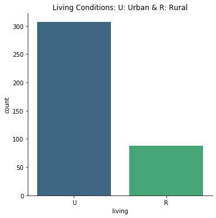

```python
sns.catplot(x="living", kind="count",palette="viridis", data=data, height = 5)
plt.title("Living Conditions: U: Urban & R: Rural")
```

# What is the gender diversity of our sample?

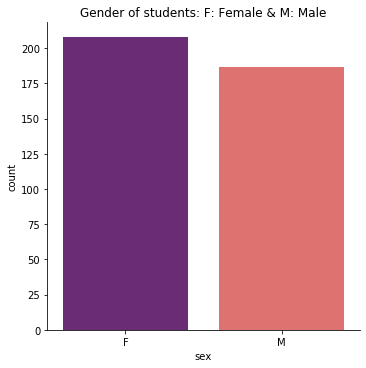

```python
sns.catplot(x="sex", kind="count",palette="magma", data=data, height = 5)
plt.title("Gender of students: F: Female & M: Male")
```

# What is the parental guidance situation?

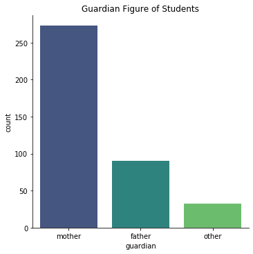

```python
sns.catplot(x="guardian", kind="count",palette="viridis", data=data, height = 5)
plt.title("Guardian Figure of Students")
```

# Who is involved in Romantic Relationships?

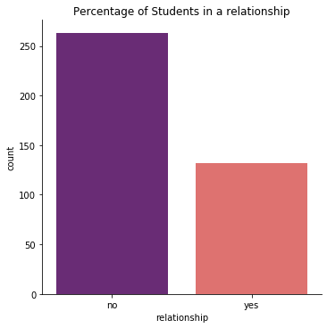

```python
sns.catplot(x="relationship", kind="count",palette="magma", data=data, height = 5)
plt.title("Percentage of Students in a relationship")
```

# How do the overall grades look for the sample size?

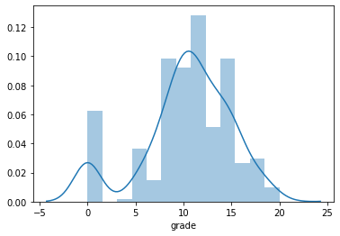

```python
sns.distplot(data['grade'])
```

# Exploratory Analysis:

Now that we have a surface level overview of what our sample data set consists of lets do a deeper exploratory analysis. Here we will dig deeper in each of the factors of academci success to see which ones have the biggest impact.

# Broad persepective on the correlation of these academic success factors....

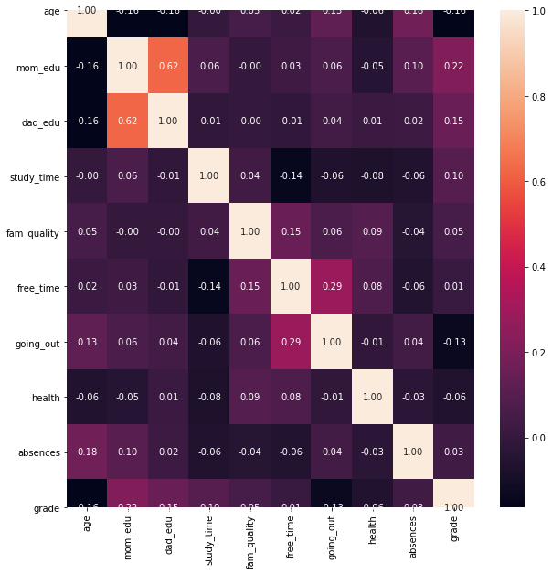

```python
plt.figure(figsize=(10,10))
sns.heatmap(data.corr(),annot = True,fmt = ".2f",cbar = True)
plt.xticks(rotation=90)
plt.yticks(rotation = 0)
```

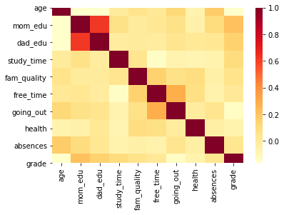

```python
sns.heatmap(data.corr(),cmap="YlOrRd")
```

# Study Time:

```python
data['st_time'] = np.nan
df = [data]

for col in df:
    col.loc[col['study_time'] == 1 , 'st_time'] = '< 2 hours'
    col.loc[col['study_time'] == 2 , 'st_time'] = '2 to 5 hours'
    col.loc[col['study_time'] == 3, 'st_time'] = '5 to 10 hours'
    col.loc[col['study_time'] == 4, 'st_time'] = '> 10 hours'

labels = data["st_time"].unique().tolist()
amount = data["st_time"].value_counts().tolist()

colors = ["pink", "cyan", "green", "yellow"]

trace = go.Pie(labels=labels, values=amount,
               hoverinfo='label+percent', textinfo='value',
               textfont=dict(size=20),
               marker=dict(colors=colors,
                           line=dict(color='#000000', width=2)))
dt = [trace]
layout = go.Layout(title="Study time")

fig = go.Figure(data=dt, layout=layout)
iplot(fig, filename='pie')
```

[interactive chart not shown]

# How time spent studying affects final grades

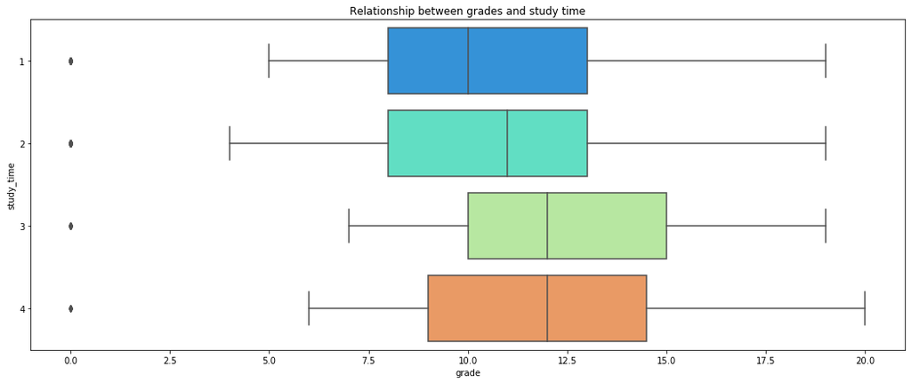

```python
plt.figure(figsize=(18,7))
plt.title("Relationship between grades and study time")
sns.boxplot(y="study_time", x="grade", data = data , orient="h", palette = 'rainbow')
```

# How Romantic relationships are affecting absences?

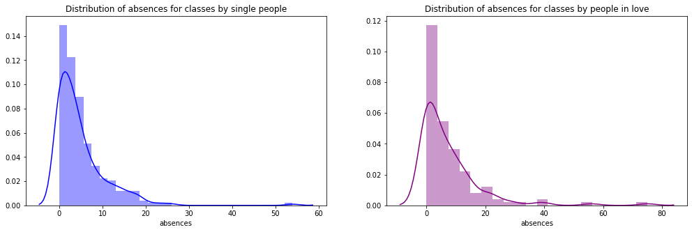

```python
f= plt.figure(figsize=(17,5))

ax=f.add_subplot(121)
sns.distplot(data[(data.relationship == 'no')]["absences"],color='blue',ax=ax)
ax.set_title('Distribution of absences for classes by single people')

ax=f.add_subplot(122)
sns.distplot(data[(data.relationship == 'yes')]['absences'],color='purple',ax=ax)
ax.set_title('Distribution of absences for classes by people in love')
```

# Does being in a romantic relationship affect their grade as well?

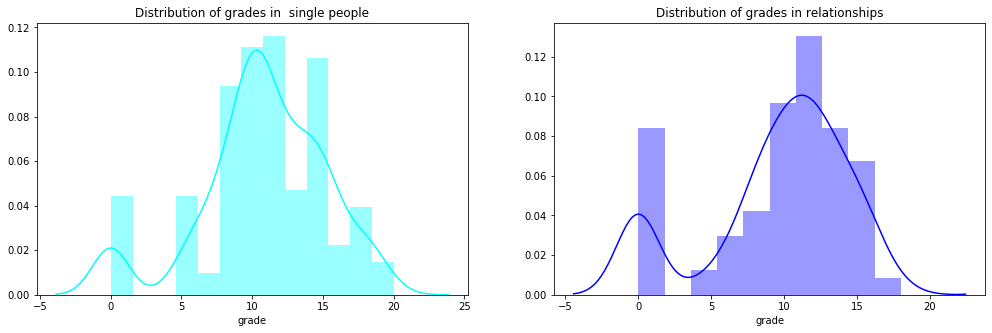

```python
f= plt.figure(figsize=(17,5))

ax=f.add_subplot(121)
sns.distplot(data[(data.relationship == 'no')]["grade"],color='cyan',ax=ax)
ax.set_title('Distribution of grades in  single people')

ax=f.add_subplot(122)
sns.distplot(data[(data.relationship == 'yes')]['grade'],color='blue',ax=ax)
ax.set_title('Distribution of grades in relationships')
```

# How poor family quality is affecting absences?

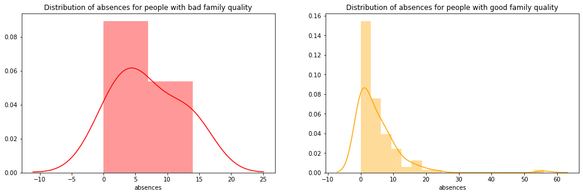

```python
f= plt.figure(figsize=(17,5))

ax=f.add_subplot(121)
sns.distplot(data[(data.fam_quality == 1)]["absences"],color='red',ax=ax)
ax.set_title('Distribution of absences for people with bad family quality')

ax=f.add_subplot(122)
sns.distplot(data[(data.fam_quality == 5)]['absences'],color='orange',ax=ax)
ax.set_title('Distribution of absences for people with good family quality')
```

# What about family quality and grades?

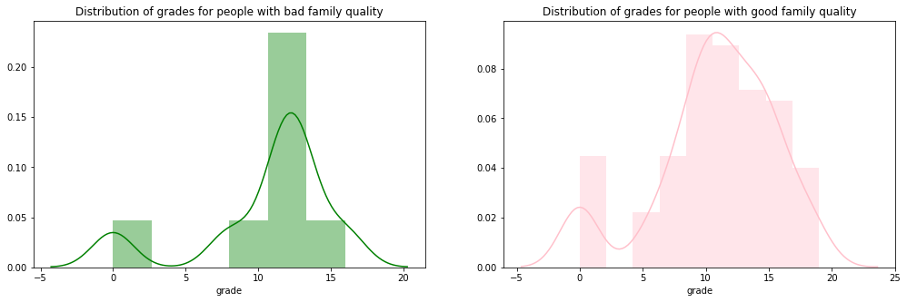

```python
f= plt.figure(figsize=(17,5))

ax=f.add_subplot(121)
sns.distplot(data[(data.fam_quality == 1)]["grade"],color='green',ax=ax)
ax.set_title('Distribution of grades for people with bad family quality')

ax=f.add_subplot(122)
sns.distplot(data[(data.fam_quality == 5)]['grade'],color='pink',ax=ax)
ax.set_title('Distribution of grades for people with good family quality')
```

# Lets look into Health..

```python
labels = data["health"].unique().tolist()
amount = data["health"].value_counts().tolist()

colors = ["coral","lightgreen","pink","cyan","white"]

trace = go.Pie(labels=labels, values=amount,
               hoverinfo='label+percent', textinfo='value',
               textfont=dict(size=20),
               marker=dict(colors=colors,
                           line=dict(color='#000000', width=2)))

dt = [trace]
layout = go.Layout(title="Current health status (numeric: from 1 - very bad to 5 - very good)")

fig = go.Figure(data=dt, layout=layout)
iplot(fig, filename = 'h_chart')
```

[interactive chart not shown]

# How does the quality of their health affect their final grade?

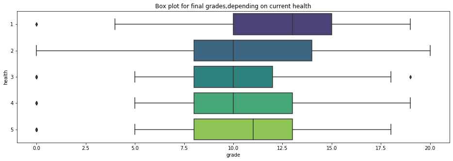

```python
plt.figure(figsize=(16,5))
plt.title("Box plot for final grades,depending on current health")
sns.boxplot(y="health", x="grade", data = data , orient="h", palette = 'viridis')
```

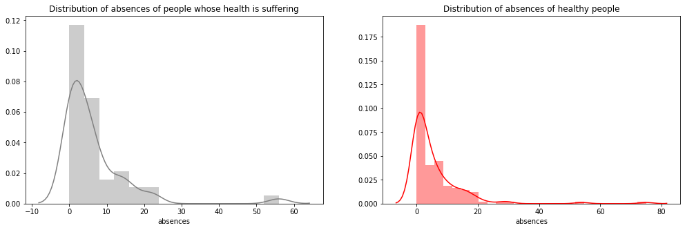

```python
f= plt.figure(figsize=(17,5))

ax=f.add_subplot(121)
sns.distplot(data[(data.health == 1)]["absences"],color='grey',ax=ax)
ax.set_title('Distribution of absences of people whose health is suffering')

ax=f.add_subplot(122)
sns.distplot(data[(data.health == 5)]['absences'],color='red',ax=ax)
ax.set_title('Distribution of absences of healthy people')
```

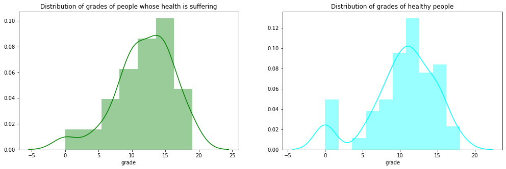

```python
f= plt.figure(figsize=(17,5))

ax=f.add_subplot(121)
sns.distplot(data[(data.health == 1)]["grade"],color='green',ax=ax)
ax.set_title('Distribution of grades of people whose health is suffering')

ax=f.add_subplot(122)
sns.distplot(data[(data.health == 5)]['grade'],color='cyan',ax=ax)
ax.set_title('Distribution of grades of healthy people')
```

# What percentage of people are involved in extra cirricular activities..

```python
ages = data["activities"].value_counts()
labels = (np.array(ages.index))
sizes = (np.array((ages / ages.sum())*100))

trace = go.Pie(labels=labels, values=sizes)
layout = go.Layout(title="Activities")
dat = [trace]
fig = go.Figure(data=dat, layout=layout)
py.iplot(fig, filename="activities")
```

[interactive chart not shown]

# Is there a correlation between activities and free time?

[figure not shown]

```python
f= plt.figure(figsize=(17,5))

ax=f.add_subplot(121)
sns.distplot(data[(data.activities == 'yes')]["free_time"],color='blue',ax=ax)
ax.set_title('Distribution of free time for people involved in extra cirricular activities')

ax=f.add_subplot(122)
sns.distplot(data[(data.activities == 'no')]['free_time'],color='red',ax=ax)
ax.set_title('Distribution of free time for people not involved in any extra cirricular activities')
```